# Introduction to exprso

Thomas Quinn

2016-04-29

## Introduction

In this tutorial, we present the *exprso* package for *R*, a custom library built to tackle a wide variety of supervised machine learning problems, including the construction of ensemble classifiers. We designed this package with the biologist user in mind, carefully assembling a toolkit that allows investigators to quickly implement dichotomous (binary) and multi-class classification on high-dimensional genomic data. We designed *exprso* using a modular framework, whereby each function acts as a self-contained, yet interchangable, part of the whole. With these modules, the investigator has access to multiple tools that they can use in almost any sequence in order to build their very own personalized machine learning pipeline. By rearranging these modules, one can easily experiment with new pipeline ideas on the fly. In this way, we balance the simplicity of automatation with endless customization, all while maintaining software extensibility.

We have bundled many kinds of functions into the *exprso* package, including functions for data import, data modification, feature selection, individual classifier construction, and ensemble classifier construction. We begin this tutorial by first presenting a brief overview of the objects and functions found in *exprso*. Then, we move on to show how the user can access this package from *GitHub* and import their own data into the *R* environment.

## exprso Objects

Before exploring the utility of the functions included in this library, we will first overview the principal object types used by this package. Objects in *R* serve as a convenient way to organize data. One can think of an object simply as a custom built data container. We emphasize these now based on the notion that a better understanding of the back-end promotes a better use of the front-end.

- **ExprsArray** Stores feature and annotation data as well as relevant feature selection history.
- **ExprsModel** Stores the trained classifier as well as the relevant feature selection history needed to deploy the classifier on an independent dataset.
- **ExprsPipeline** Stores a summary of high-throughput classifier performance and the classifier objects themselves.
- **ExprsEnsemble** Stores any number of classifier objects which function a single ensemble classifier.
- **ExprsPredict** Stores the results of classifier prediction as one of three measures.

## exprso Functions

The functions included in this package rely on the objects listed above. Some of these functions return an updated version of the same object type provided, while others return a different object type altogether. We have adopted a function nomenclature to help the user organize the functions available in this package. In this scheme, most functions have a few letters in the beginning of their name which designate their general utility. Below, we include a brief description of function prefixes along with a flow diagram of all available functions.

- **array** Any function that has a role in importing or subsetting data. Returns an updated `ExprsArray` object.
- **mod** Any function that has a role in pre-processing `ExprsArray` objects. Returns an updated `ExprsArray` object.
- **split** Any function that has a role in splitting `ExprsArray` objects into training and test sets. Returns a list of two `ExprsArray` objects.
- **fs** Any function that has a role in feature selection. Returns an updated `ExprsArray` object.
- **build** Any function that has a role in building a classifier or classifier ensemble. Returns an `ExprsModel` or `ExprsEnsemble` object.
- **pl** Any function that has a role in high-throughput analytics. Usually returns an `ExprsPipeline` object.
- **pipe** Any function that has a role in post-processing `ExprsPipeline` objects. Returns an updated `ExprsPipeline` object.

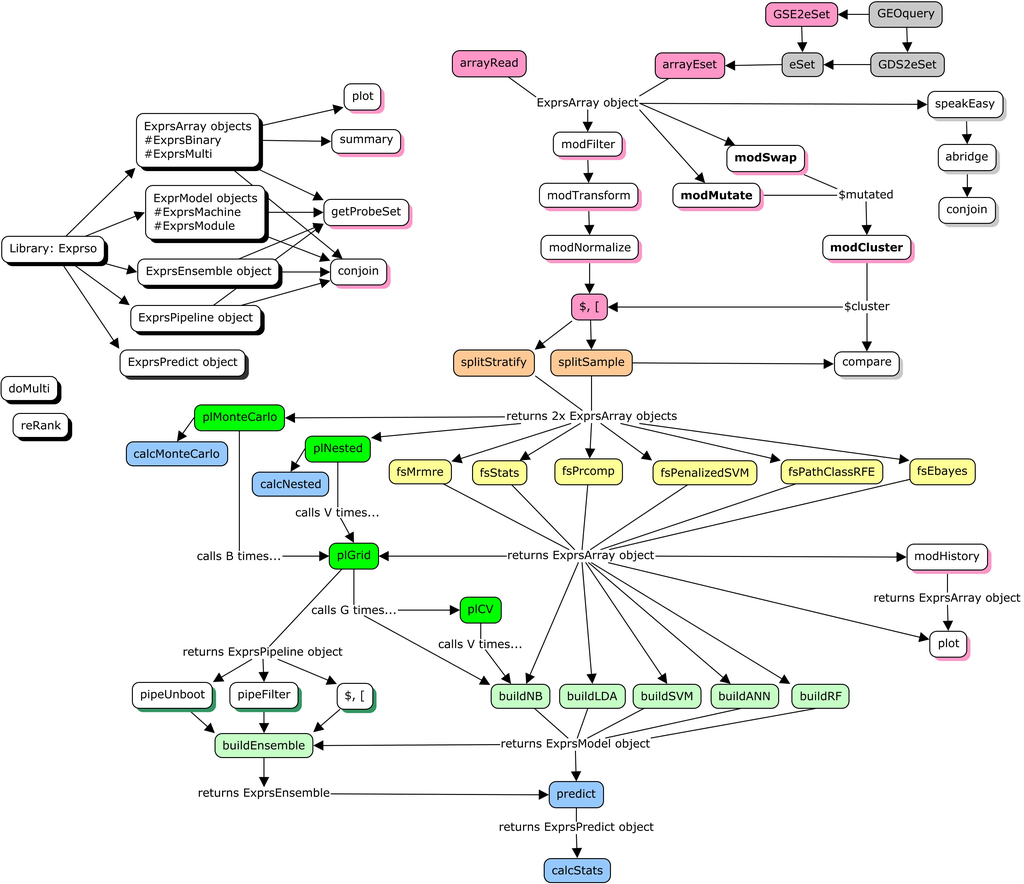

## Importing the library

We can load the most recent version of *exprso* directly from *GitHub* using the `install_github` function provided by the *devtools* package.

```r
library(devtools)
devtools::install_github("tpq/exprso")
```

```r
library(exprso)
```

## Importing data

With *exprso* loaded, we can import data in one of three ways. First, we can import data as stored locally in a tab-delimited text file. The construction of this import function, `arrayRead`, assumes the data file contains the subjects as rows and variables as columns, with annotation variables (e.g., sex or age) appearing before the feature variables (e.g., mRNA expression values). The `include` argument lists any number of annotation vectors to assign to each class label. In the example below, we assign the annotation “Control” to the first class; then, we assign the annotations “ASD” and “PDDNOS” to the second class. Any subjects not assigend to a class will get dropped from the resultant object.

```r
array <-
  arrayRead("some_example_data_file.txt", # tab-delimited file
            probes.begin = 11, # the i-th column where features begin
            colID = "Subject.ID", # column name with subject ID
            colBy = "DX", # column name with class labels
            include = list(c("Control"), c("ASD", "PDDNOS")))
```

Second, we can construct an `ExprsArray` object manually using the `new` function. To accomplish this, we need to define the four slots found which comprise an `ExprsArray` object. The `@exprs` slot must contain a feature value `matrix` with subject names as columns. The `@annot` slot must contain an annotation `data.frame` with subject names as rows. It is critical to make sure that the subject names appear in the same order across both data structures. The two additional slots, `@preFilter` and `@reductionModel`, pass along the feature selection history while deploying built machines. When constructing an `ExprsArray` object manually, we should set both of these to `NULL`.

```r
array <-
  new("ExprsArray",
      exprs = some.expression.matrix,
      annot = some.annotation.data.frame,
      preFilter = NULL,
      reductionModel = NULL)
```

Third, we can import data directly by converting an `eSet` object, a popular container for storing gene expression data, using the function `arrayEset`. In the example below, we convert the classic ALL/AML Golub gene expression dataset from an `eSet` object (provided by the *golubEsets* package) into an `ExprsArray` object.

```r
library(golubEsets)
data(Golub_Merge)
array <-
  arrayEset(Golub_Merge, # an ExpressionSet (abrv. eSet) object
            colBy = "ALL.AML", # column name with class labels
            include = list("AML", "ALL"))
```

## Subsetting data

For quickly subsetting `ExprsArray` objects by subject annotations, we provide methods for the `[` and `$` operators that access the `@annot` annotations slot directly. Below, we will use these operators to subset the “ALL.AML” column of the `ExprsArray` object subjects assigned the “Case” class label.

```r
array[array$defineCase == "Case", "ALL.AML"]
```

```
##  [1] ALL ALL ALL ALL ALL ALL ALL ALL ALL ALL ALL ALL ALL ALL ALL ALL ALL
## [18] ALL ALL ALL ALL ALL ALL ALL ALL ALL ALL ALL ALL ALL ALL ALL ALL ALL
## [35] ALL ALL ALL ALL ALL ALL ALL ALL ALL ALL ALL ALL ALL
## Levels: ALL AML
```

## Splitting data

When performing classification, an investigator will typically withhold some percentage of the data in order to assess classifier performance, splitting the data into two. The first dataset, called the *training set*, gets used to train the model, while the other, called the external validation or *test set*, gets used to evaluate the model. This package offers two convenience functions for splitting the data, `splitSample` and `splitStratify`. The former builds the training set based on simple random sampling (with or without replacement), assigning the remaining subjects to the test set. The latter builds the training set using stratified random sampling. These functions both return a list of two `ExprsArray` objects corresponding to the training set and test set respectively. Below, we use the `splitStratify` function to build the training and test sets through a stratified random sample across the dichotomous (binary) classification annotation.

```r
arrays <-
  splitStratify(array,
                percent.include = 67,
                colBy = NULL)
```

```
##
## Pre-stratification table:
## df
##    Case Control
##      47      25
##
## Weighted stratification results:
##
##    Case Control
##      17      17
```

```r
array.train <- arrays[[1]]
```

## Balancing data

Above, all subjects not included in the training set (based on `percent.include`) will automatically get assigned to the test set. When using `splitStratify` on a dataset with an unequal number of annotated subjects (e.g., more cases than controls), the resultant test set may contain relative annotation frequencies that differ from the training set. We can fix this so-called “imbalance” at the cost of reducing sample size by performing `splitStratify` a second time. Now, we will use the test set as the input and let `percent.include = 100` (keeping the other parameters the same). This will split the test set such that the new “training set” (i.e., slot 1) now contains the *balanced test set* and the new “test set” (i.e., slot 2) now contains the “spillover” due to balancing.

```r
balance <-
  splitStratify(arrays[[2]],
                percent.include = 100,
                colBy = NULL)
```

```
##
## Pre-stratification table:
## df
##    Case Control
##      30       8
##
## Weighted stratification results:
##
##    Case Control
##       8       8
```

```r
array.test <- balance[[1]]
```

For more information, we refer the user to the package documentation, `?split`.

## Selecting features

Considering the high-dimensionality of most genomic datasets, it is prudent and often necessary to prioritize which features to include during classifier construction. There exists a myriad of ways to perform the task of *feature selection*. This package provides functions for some of the most frequently used feature selection methods. Each function works as a self-contained wrapper that (1) pre-processes the `ExprsArray` input, (2) performs the feature selection, and (3) returns an `ExprsArray` output with an updated feature selection history.

These feature selection histories get passed along at every step of the way until they eventually get used in order to pre-process an unlabelled dataset during classifier deployment (i.e., prediction). In the spirit of open source programming, we encourage users to submit their own feature selection functions, modeled after those provided in this library.

The first of these feature selection functions, `fsStats`, performs some of the most basic feature selection methods: those rooted in simple statistical tests. Specifically, this function will rank probes based on either the Student’s *t*-test or the Kolmogorov-Smirnov test. Below, we rank features according to the results of a Student’s *t*-test.

```r
array.train <-
  fsStats(array.train, probes = 0, how = "t.test")
```

On first exposure, we acknowledge that the argument `probes` might seem confusing. Therefore, we wish to emphasize the role of this term in specifying either the names or the number of features to supply *to* feature selection: it does not refer to what the user intends to retrieve *from* the feature selection process. When calling the first feature selection method with a numeric *probes* argument, it will draw from the “top ranked” probe set that actually refers to the default order in which the features appear in the `ExprsArray` input. However, each successful feature selection will return an `ExprsArray` output with the features implicitly (re-)ranked. Therefore, when calling a subsequent feature selection method, the “top ranked” probe set will indeed correspond to the feature ranks from the previous feature selection process. For example, the third feature selection call draws the top probes from the second feature ranking. The user may deploy, in tandem, any number of these functions in whatever order they choose, limited only by computational power and imagination.

Another included feature selection method, `fsPrcomp`, performs dimension reduction by way of principal components analysis (**PCA**). The dimension reduction model generated during this function call gets saved in the feature selection history along with the compontents themselves. Below, we subject the top 50 probes as prioritized by `fsStats` to PCA.

```r
array.train <-
  fsPrcomp(array.train, probes = 50)
```

```
##
## Dimension reduction model summary:
##
## Importance of components:
##                              PC1       PC2       PC3       PC4       PC5
## Standard deviation     1.067e+04 4.006e+03 3.266e+03 2.993e+03 2.067e+03
## Proportion of Variance 6.627e-01 9.349e-02 6.214e-02 5.219e-02 2.489e-02
## Cumulative Proportion  6.627e-01 7.562e-01 8.184e-01 8.705e-01 8.954e-01
##                              PC6       PC7       PC8       PC9      PC10
## Standard deviation     1916.7152 1.620e+03 1.484e+03 1.312e+03 1.220e+03
## Proportion of Variance    0.0214 1.529e-02 1.282e-02 1.002e-02 8.660e-03
## Cumulative Proportion     0.9168 9.321e-01 9.449e-01 9.550e-01 9.636e-01
##                             PC11      PC12      PC13      PC14     PC15
## Standard deviation     1.140e+03 938.21673 821.00296 770.10020 740.8781
## Proportion of Variance 7.570e-03   0.00513   0.00393   0.00345   0.0032
## Cumulative Proportion  9.712e-01   0.97631   0.98024   0.98369   0.9869
##                             PC16      PC17      PC18      PC19     PC20
## Standard deviation     636.10488 588.57037 553.75913 460.44113 434.9045
## Proportion of Variance   0.00236   0.00202   0.00179   0.00123   0.0011
## Cumulative Proportion    0.98925   0.99127   0.99305   0.99429   0.9954
##                             PC21      PC22      PC23      PC24      PC25
## Standard deviation     412.27893 339.30484 331.35028 302.93659 274.82478
## Proportion of Variance   0.00099   0.00067   0.00064   0.00053   0.00044
## Cumulative Proportion    0.99638   0.99705   0.99769   0.99822   0.99866
##                             PC26      PC27      PC28      PC29      PC30
## Standard deviation     229.22201 200.72480 195.17217 179.37024 170.09928
## Proportion of Variance   0.00031   0.00023   0.00022   0.00019   0.00017
## Cumulative Proportion    0.99897   0.99920   0.99943   0.99961   0.99978
##                             PC31     PC32     PC33      PC34
## Standard deviation     152.97388 90.53905 77.15520 9.291e-13
## Proportion of Variance   0.00014  0.00005  0.00003 0.000e+00
## Cumulative Proportion    0.99992  0.99997  1.00000 1.000e+00
```

The other feature selection methods included in this package all follow the same use pattern. Below, we plot the first three components of the training set in 3-dimensional space.

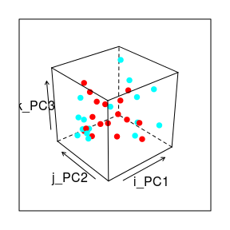

```r
plot(array.train)
```

For more information, we refer the user to the package documentation, `?fs`.

## Constructing classifiers

This package exposes several methods for supervised machine learning, including wrapper functions that implement support vector machines, artificial neural networks, random forests, and more. These functions require an `ExprsArray` object as input and return a single `ExprsModel` object as output. This `ExprsModel` object contains the feature selection history that led up to classifier construction as well as the classifier itself. Below, we build an artificial neural network with five intermediate nodes in the hidden layer using the top 10 components from the *training set* above.

```r
mach <-
  buildANN(array.train, probes = 10, size = 5)
```

```
## Setting 'range' to 1/max(|x|) (default behavior, override explicitly)...
## Setting 'decay' to 0.5 (default behavior, override explicitly)...
## Setting 'maxit' to 1000 (default behavior, override explicitly)...
```

For more information, we refer the user to the package documentation, `?build`.

## Deploying classifiers

We deploy an `ExprsModel` object using `predict`. This function returns an `ExprsPredict` object containing the prediction results in three forms: prediction, probability, and decision boundary predictions. The probability and decision boundary predictions relate to one another by a logistic transformation. The prediction (`@pred`) slot converts these metrics into a single “all-or-nothing” class label assignment.

Another function, `calcStats`, allows us to compare the prediction results (as stored within an `ExprsPredict` object) against the actual diagnostic labels found in the corresponding `ExprsArray` object. The `aucSkip` argument specifies whether to calculate the area under the receiver operating characteristic (**ROC**) curve.

We note here that performance metrics calculated using the ROC curve may differ from those calculated using a confusion matrix because the former may adjust the discrimination threshold to optimize sensitivity and specificity. The discrimination threshold is automatically chosen as the point along the ROC curve which minimizes the Euclidean distance from (0, 1). Below, we deploy a classifier on the *test set*, then use the result to calculate classifier performance.

```r
pred <-
  predict(mach, array.test)
```

```
## Individual classifier performance:
## Arguments not provided in an ROCR AUC format. Calculating accuracy outside of ROCR...
## Classification confusion table:
##          actual
## predicted Control Case
##   Control       8    0
##   Case          0    8
##   acc sens spec
## 1   1    1    1
```

```r
calcStats(pred, array.test)
```

```
## Calculating accuracy using ROCR based on prediction probabilities...
```

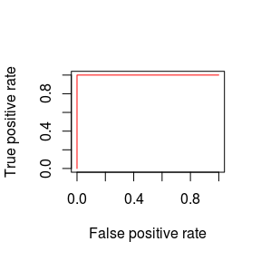

```
##   acc sens spec auc
## 1   1    1    1   1
```

For more information, we refer the user to the package documentation, `?'exprso-predict`.

## Pipeline methods

This package includes several functions named with the prefix `pl`. These “pipeline” functions exist to help consolidate high-throughput analyses. In other words, they wrap repetitive tasks into a single operation. Such tasks include high-throughput parameter searches as well as some elaborate cross-validation designs. As we will see, some of these `pl` functions will even have other `pl` functions embedded within them. For example, the function `plGrid` contains the function `plCV` for managing *v*-fold and leave-one-out cross-validation.

## High-throughput parameter searches

When constructing a classifier using a **build** method, we can only specify one set of parameters at a time. However, we often want to test models across a vast range of parameters. For this task, we provide the `plGrid` function. This function builds and deploys a model for each combination of all provided arguments. For example, calling `plGrid` with the arguments `how = "buildSVM"`, `probes = c(3, 5, 10)`, `cost = 10^(-3:3)`, and `kernel = c("linear", "radial")` will yield 42 classifiers.

We note here that this function only accepts one `how` per run. To analyze the results of multiple `build` parameter searches jointly, combine the results of those `plGrid` function calls using `?conjoin`. We will also note that `plGrid` does not execute any data splitting or feature selection, both of which the user may perform beforehand. However, `plGrid` does allow the user to specify multiple *classifier sizes* by providing a numeric vector as the `probes` argument.

The `plGrid` function can also calculate *v*-fold cross-validation accuracy at each step of the parameter search (toggled by supplying a non-`NULL` argument to `fold`). We emphasize, however, that the cross-validation method embedded within `plGrid` (i.e., `plCV`) does not re-select features with each fold, which may lead to overly-optimistic measures of classifier performance in the setting of prior feature selection.

Below, we will run through a few different support vector machine (SVM) builds, calculating the leave-one-out cross-validation accuracy (by setting `fold = 0`) at each step.

```r
gs <-
  plGrid(array.train = array.train,
         array.valid = array.test,
         probes = 0,
         how = "buildSVM",
         fold = 0,
         kernel = "linear",
         cost = 10^(-3:3)
)
```

The returned object contains two slots, `@summary` and `@machs`, which store the performance summary and corresponding `ExprsModel` objects, respectively. The performance summary contains columns detailing the parameter used to build each machine along with performance metrics for the training set (and test set, if provided). Columns named with “train” describe training set performances. Columns named with “valid” describe test set performances. The column, `"train.plCV"`, contains the cross-validation accuracy, if performed. The returned `ExprsPipeline` object also contains an `ExprsModel` object for each entry in the performance summary.

We can subset `ExprsPipeline` objects based on the performance summary (i.e., `@summary`) by using the `[` and `$` operators, similar to how `ExprsArray` object subsetting works. Below, we extract the column that contains the cross-validation accuracies using `[` and `$`.

```r
gs[, "train.plCV"]
```

```
## [1] 1.0000000 0.8823529 0.4705882 0.4705882 0.5294118 0.5588235 0.5294118
```

```r
gs$train.plCV
```

```
## [1] 1.0000000 0.8823529 0.4705882 0.4705882 0.5294118 0.5588235 0.5294118
```

## Other cross-validation

The *exprso* package also provides a means by which to perform elaborate cross-validation, including Monte Carlo style and 2-layer “nested” cross-validation. Analogous to how `plGrid` manages multiple build and predict tasks, these pipelines (i.e., `plMonteCarlo` and `plNested`) effectively manage multiple `plGrid` tasks. In order to organize the sheer number of arguments necessary to execute these functions, we have implemented argument handler functions. These argument handler functions (i.e., `ctrlSplitSet`, `ctrlFeatureSelect`, and `ctrlGridSearch`) handle the data splitting, feature selection, and grid searching arguments, respectively.

In simplest terms, `plMonteCarlo` and `plNested` use a single training set to calculate classifier performances on a withheld *internal validation set*. This *internal validation set* serves as a kind of proxy for a statistically independent test set. The main difference between `plMonteCarlo` and `plNested` stems from how *internal validation set* gets constructed. On one hand, the `plMonteCarlo` method uses the `ctrlSplitSet` argument handler to split the training set into a *training subset* and an *intenral validation set* with each boostrap. On the other hand, the `plNested` method splits the training set into *v*-folds, treating each fold as an *internal validation set*, with the remaining subjects comprising the *training subset*.

For the sake of simplicity, we will call any performance measured on an *internal validation set* as the **outer-loop** cross-validation performance. Then, we will call any cross-validation accuracy measured using the *training subset* (i.e., via `plGrid`) the **inner-loop** cross-validation performance. In the performance summaries of the `ExprsPipeline` objects returned by `plMonteCarlo` and `plNested`, columns named with “train” describe *training subset* performances while columns named with “valid” describe *internal validation set* performances.

Although the **inner-loop** cross-validation performances (i.e., via `plCV`) can still over-estimate cross-validation through prior feature selection, the **outer-loop** cross-validation performances derive from classifiers that have undergone feature selection anew with each bootstrap or fold. However, we emphasize here that performing feature selection on a training set *prior* to the use of `plMonteCarlo` or `plNested` can still result in overly optimistic **outer-loop** cross-validation performances.

```r
ss <-
  ctrlSplitSet(func = "splitSample", percent.include = 67, replace = TRUE)
fs <-
  ctrlFeatureSelect(func = "fsStats", probes = 0, how = "t.test")
gs <-
  ctrlGridSearch(func = "plGrid",
                 how = "buildSVM",
                 probes = c(10, 25, 50),
                 kernel = "linear",
                 cost = 10^(-3:3),
                 fold = 10)
```

```r
boot <-
  plMonteCarlo(balance[[1]],
               B = 5,
               ctrlSS = ss,
               ctrlFS = fs,
               ctrlGS = gs)
```

Next, we reduce the results of `plMonteCarlo` to a single performance metric by feeding the returned `ExprsPipeline` object through `calcMonteCarlo`.

```r
calcMonteCarlo(boot, colBy = "valid.auc")
```

```
## Retrieving best accuracy for boot 1 ...
## Retrieving best accuracy for boot 2 ...
## Retrieving best accuracy for boot 3 ...
## Retrieving best accuracy for boot 4 ...
## Retrieving best accuracy for boot 5 ...
## Averaging best accuracies across all boots...
```

```
## [1] 0.7375
```

## Ensemble classifiers

This package provides two ways to build ensemble classifiers. The first involves manually combining multiple `ExprsModel` objects together through the function `buildEnsemble` (or `?conjoin`). The second involves an orchestrated manipulation of an `ExprsPipeline` object through the `pipeFilter` function.

When calling the `buildEnsemble` method for an `ExprsPipeline` object, any classifiers remaining after the `pipeFilter` filter will get assembled into a single ensemble classifier. Ensemble classifiers get stored as an `ExprsEnsemble` object which is nothing more than object-oriented container for a list of multiple `ExprsModel` objects.

```r
ens <- buildEnsemble(boot, top.N = 1, colBy = "valid.auc")
```

```r
predict(ens, array.test, how = "probability")
```

```
## Individual classifier performance:
## Arguments not provided in an ROCR AUC format. Calculating accuracy outside of ROCR...
## Classification confusion table:
##          actual
## predicted Control Case
##   Control       7    1
##   Case          1    7
##     acc  sens  spec
## 1 0.875 0.875 0.875
## Individual classifier performance:
## Arguments not provided in an ROCR AUC format. Calculating accuracy outside of ROCR...
## Classification confusion table:
##          actual
## predicted Control Case
##   Control       7    2
##   Case          1    6
##      acc sens  spec
## 1 0.8125 0.75 0.875
## Individual classifier performance:
## Arguments not provided in an ROCR AUC format. Calculating accuracy outside of ROCR...
## Classification confusion table:
##          actual
## predicted Control Case
##   Control       8    2
##   Case          0    6
##     acc sens spec
## 1 0.875 0.75    1
## Individual classifier performance:
## Arguments not provided in an ROCR AUC format. Calculating accuracy outside of ROCR...
## Classification confusion table:
##          actual
## predicted Control Case
##   Control       8    0
##   Case          0    8
##   acc sens spec
## 1   1    1    1
## Individual classifier performance:
## Arguments not provided in an ROCR AUC format. Calculating accuracy outside of ROCR...
## Classification confusion table:
##          actual
## predicted Control Case
##   Control       7    2
##   Case          1    6
##      acc sens  spec
## 1 0.8125 0.75 0.875
## Ensemble classifier performance:
## Arguments not provided in an ROCR AUC format. Calculating accuracy outside of ROCR...
## Classification confusion table:
##          actual
## predicted Control Case
##   Control       8    1
##   Case          0    7
##      acc  sens spec
## 1 0.9375 0.875    1
```

```
## @pred summary: 2 1 2 2 2 2 2 2 1 1 1 1 1 1 1 1
## @decision.values summary: Case/Control
## @probability summary: Control Case
```

Owing to how the `pipeFilter` function handles `ExprsPipeline` objects that contain a “boot” column in the performance summary (i.e., `@summary`), we include the `pipeUnboot` function to rename this “boot” column to “unboot”. To learn more about how `ExprsEnsemble` predicts class labels, we refer the user to the package documentation, `?'exprso-predict'`. In addition, we encourage the user to visit the package documentation, `?'ExprsPipeline-class'` and `?'ExprsEnsemble-class'`, for more information on pipelines and ensembles, respectively.

## Multi-class methods

We conclude this vignette by alerting the user that the *exprso* package also includes a framework for performing multi-class classification in an automated manner. These methods use the “1-vs-all” approach to multi-class classification, whereby each individual class label has a turn getting treated as the positive class label in a dichotomous (binary) scheme. Then, the results of each iteration get integrated into a single construct. To learn more about multi-class classification, we refer the user to the package documentation, `?arrayRead` and `?doMulti`. However, we wish to emphasize here that multi-class feature selection is still under heavy development. In the near future, we plan to introduce novel `pl` methods that implement multi-class feature selection in an optimal manner.

## Final remarks

Thank you for your interest in *exprso*. Although we have made tremendous progress in formalizing this library in a reliable package framework, some of the tools included here may eventually change. We will make our best effort to keep this vignette and other documentation as up-to-date as possible. However, we may occasionally fall short on this goal. In face of any discrepancy, we encourage the reader to send any and all questions to the package maintainer (e-mail: thom@tpq.me). In addition, we welcome suggestions for new tools that we could bundle into future installments.